# Litter Observations

Litter is a growing issue in the environment today, impacting ecological and human health. I wanted to investigate the patterns of litter that I observed in my day-to-day life in the outdoor environment. To better target waste management initiatives, it is necessary to understand the litter distribution. Therefore, I explored data about litter quantity, bin characteristics, location, category, and time.

## Litter Quantity

[figure not shown]

Bar Chart of frequency of Litter Quantity

When I encountered litter in the environment, I counted the number of pieces within an approximately 2 metres by 2 metres square. The frequency of litter quantities plot demonstrates a right skew; low quantities of litter were observed most frequently, whereas larger quantities were observed less often.

## Do Rubbish Bins Make a Difference?

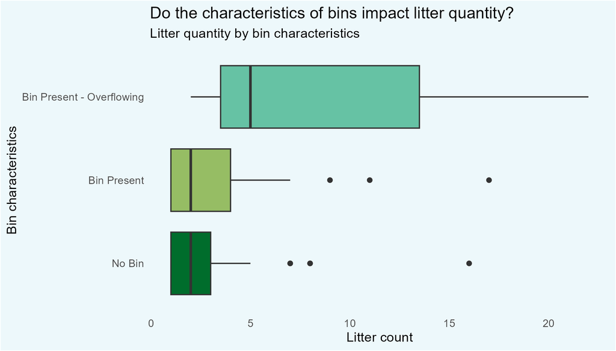

Box plot of litter quantity by bin type

Whether a bin is present or absent doesn’t make much difference in the quantities of litter observed. However, if the bin was overflowing, a greater quantity of litter was observed. This is likely due to spill-over exacerbated by wind, causing large amounts of litter to accumulate in a single area.

[figure not shown]

## Locaton of Litter

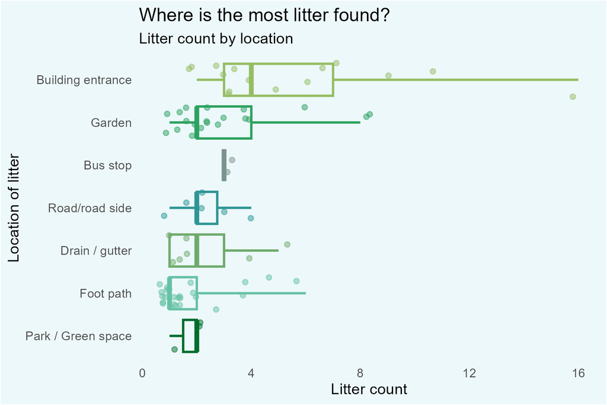

Box plots of litter quantity by location

The highest quantities of litter tend to be found in building entrances. Wind may contribute to this pattern by blowing litter into a sheltered area where it becomes “trapped”. A similar mechanism causes litter to become stuck in gardens, likely contributing to the high quantities observed. Footpaths and parks/green spaces tended to have low counts of litter. People or wind easily move the litter on footpaths, which may contribute to the diffuse pattern of low count litter observations. However, it is also important to note that my travel patterns influence these observations, where I frequently visit certain areas more than others, which may be reflected in the data.

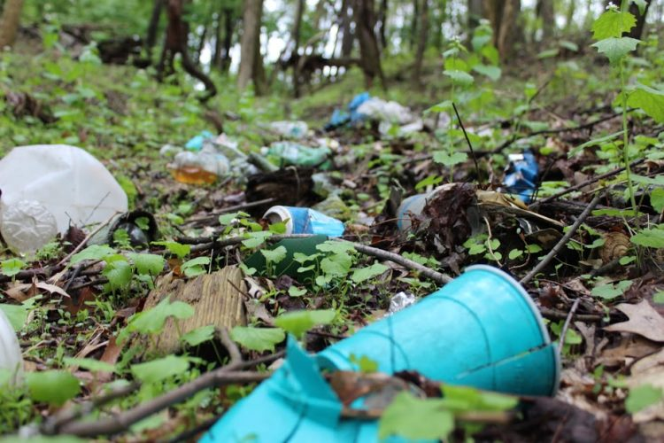

## Which Litter Type is Most Common?

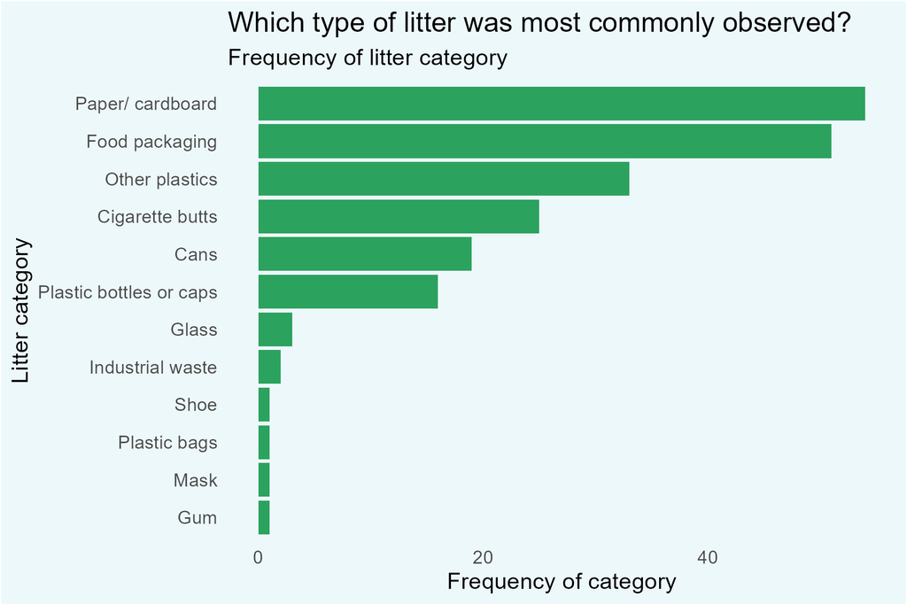

Column plot of litter category frequency

Paper/cardboard was the most frequently observed litter category, followed by food packaging. This plot demonstrates the number of times an observation of a particular litter type occurred, not the total count of each category. Through my observations I noted that there were large quantities of cigarette butts grouped together which is not explicitly captured in this plot.

## Time of Litter Observations

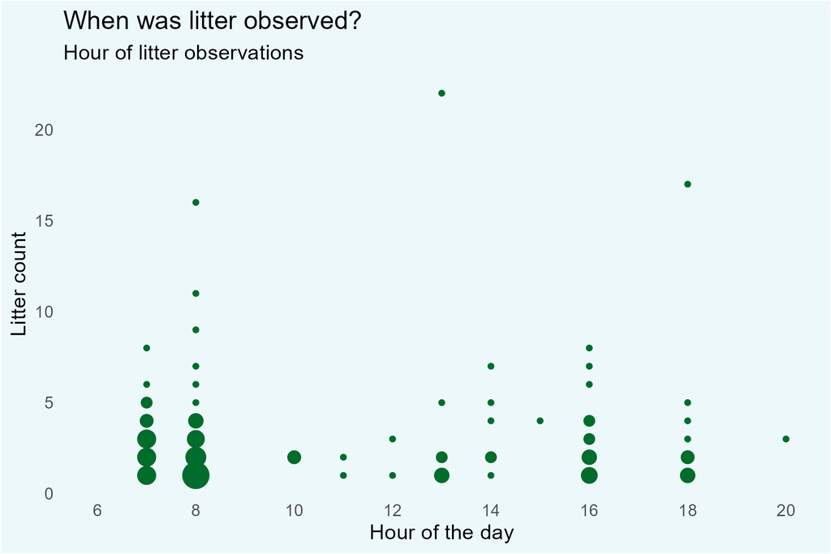

Count plot of hour of litter observation

Litter observations frequently occurred in the morning, between 07:00 and 08:00. This pattern of observation largely reflects the time that I commute to university or work, in which I walk along highly trafficked, main roads, resulting in a large number of litter observations. The time that I leave university or work is more variable daily. Therefore, fewer observations are made in the afternoon/ evening than in the morning. The observations that occur in the middle of the day, approximately between 09:00 and 15:00, tend to be observations of litter at university as I walk between classes on the University of Auckland campus.